# Modifying Layouts and Aesthetics

David Gerard

2020-10-15

# Learning Objectives

- Learn the basics layouts.
- [Application Layout Guide](http://shiny.rstudio.com/articles/layout-guide.html).
- [Shiny Cheatsheet](https://github.com/rstudio/cheatsheets/blob/master/shiny.pdf).
- Optional Resources
  - [Shiny Tutorial](https://stat545.com/shiny00_index.html).
  - [Shiny Video, Part 3](https://vimeo.com/rstudioinc/review/131218530/212d8a5a7a/#t=1h32m41s).
  - [Shiny Examples](https://github.com/rstudio/shiny-examples).

# Motivation

- Let’s start with a blank Shiny app

  ```r
  library(shiny)

  ui <- fluidPage(

  )

  server <- function(input, output) {

  }

  shinyApp(ui = ui, server = server)
  ```

- You learned in [The Basics of Shiny Apps](https://data-science-master.github.io/lectures/06_shiny/06_basic_shiny.html) how to add input and output elements to the user interface of an app.
- But the way we added elements was ugly.

[figure not shown]

  ```r
  library(shiny)
  library(ggplot2)

  ui <- fluidPage(
      selectInput("var", "Which Variable?", choices = names(mtcars)),
      plotOutput("plot")
  )

  server <- function(input, output) {
      output$plot <- renderPlot({
          ggplot(mtcars, aes(x = .data[[input$var]])) +
              geom_histogram(bins = 20)
      })
  }

  shinyApp(ui = ui, server = server)
  ```

- Today, we will learn how to make your layout more sophisticated than a list of items.

# Basic Layouts

- The most basic layouts are created by adding arguments to the `fluidPage()` function.
  - You add arguments to `fluidPage()` to specify the layout of your app.
- We’ll also talk about grid layouts later, but to see more advanced layouts try out:
  - `navbarPage()`.
  - `dashboardPage()`: https://rstudio.github.io/shinydashboard/
  - Enhanced `dashboardPage()`: https://rinterface.github.io/shinydashboardPlus/

## Title Panel

- Add a title to your app using the `titlePanel()` function.

  ```r
  library(shiny)

  ui <- fluidPage(
      titlePanel("My First Title")
  )

  server <- function(input, output) {

  }

  shinyApp(ui = ui, server = server)
  ```

- Running the app, you should get something like this:

[figure not shown]

## Sidebar Layout

- The most basic layout is to have inputs in a left column and outputs in a right column. You use `sidebarLayout()` to specify that you want this structure.
- *Inside* `sidebarLayout()`, you define the left column inputs via `sidebarPanel()` and the right column outputs via `mainPanel()`.
- Let’s create an app that plots random normal draws:

  ```r
  library(shiny)
  library(ggplot2)

  ui <- fluidPage(
    titlePanel("Random Normal Histogram"),
    sidebarLayout(
      sidebarPanel(
        sliderInput("nobs", "Number of Observations", min = 1, max = 500, value = 100)
      ),
      mainPanel(
        plotOutput("hist")
      )
    )
  )

  server <- function(input, output) {
    output$hist <- renderPlot({
      rout <- data.frame(x = rnorm(n = input$nobs))
      ggplot(rout, aes(x = x)) +
        geom_histogram(bins = 30) +
        theme_bw()
    })
  }

  shinyApp(ui = ui, server = server)
  ```

- Running the app, you should get something like this:

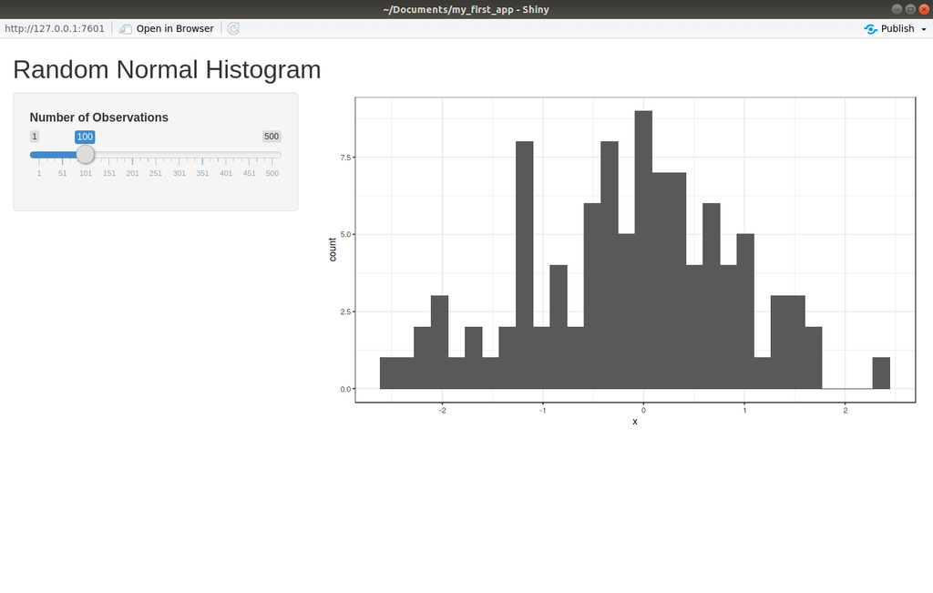

- `sidebarPanel()`:
  - An argument of `sidebarLayout()`.
  - Takes as input an input element (such as `sliderInput()`, `textInput()`, etc).
  - You can include multiple input elements by separating them by a comma.
- `mainPanel()`:
  - An argument of `sidebarLayout()`.
  - Takes as input an output element (such as `plotOutput()`, `textOutput()`, etc).
  - You can include multiple output elements by separating them by a comma.
- Hadley’s Graphic:

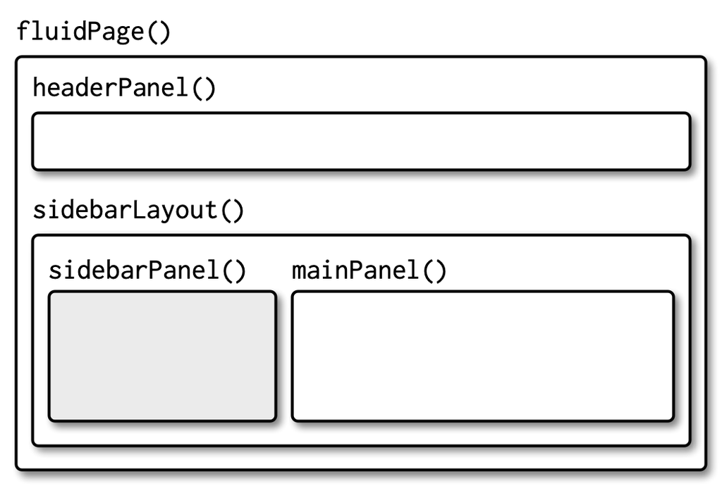

- If you put input elements in `mainPanel()` and output elements in `sidebarPanel()`, then the app won’t die (but it won’t look as nice).
- **Exercise**: Create a Shiny app with the sidebar layout. The inputs should be the number of bins, the plot title, and which variable to plot from `mtcars`. The output should be a histogram. Add a nice shiny app title.

  Your final Shiny App should look like this:

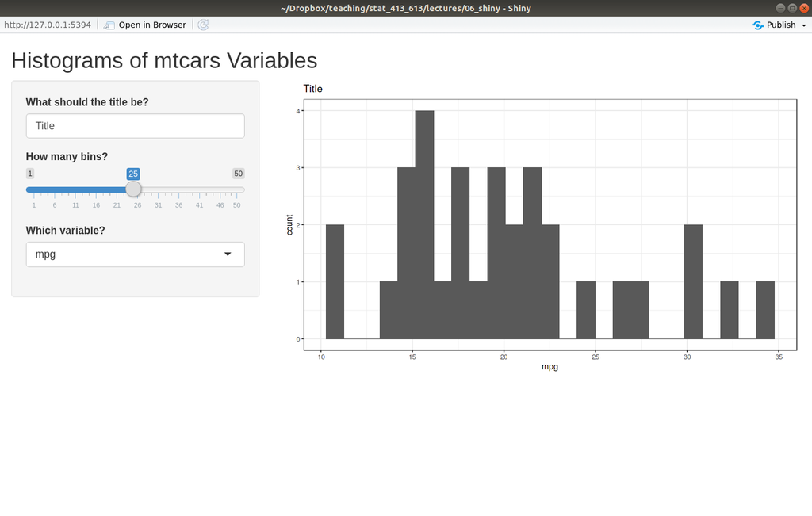

## Grid Layout

- To create a general layout, use the `fluidRow()` and `column()` functions.
- `fluidRow()`
  - Creates a new row of panels.
  - Takes `column()` calls as input.
  - You place as many `column()` calls as you want columns.
  - It can have a title.
- `column()`
  - Used as an argument in `fluidRow()`.
  - The first argument should be a number between 1 and 12 (the `width`).
  - All `column()` calls should have `width`s that sum to 12.
  - The rest of the arguments are input/output elements to include in that column.
- Hadley’s Graphic:

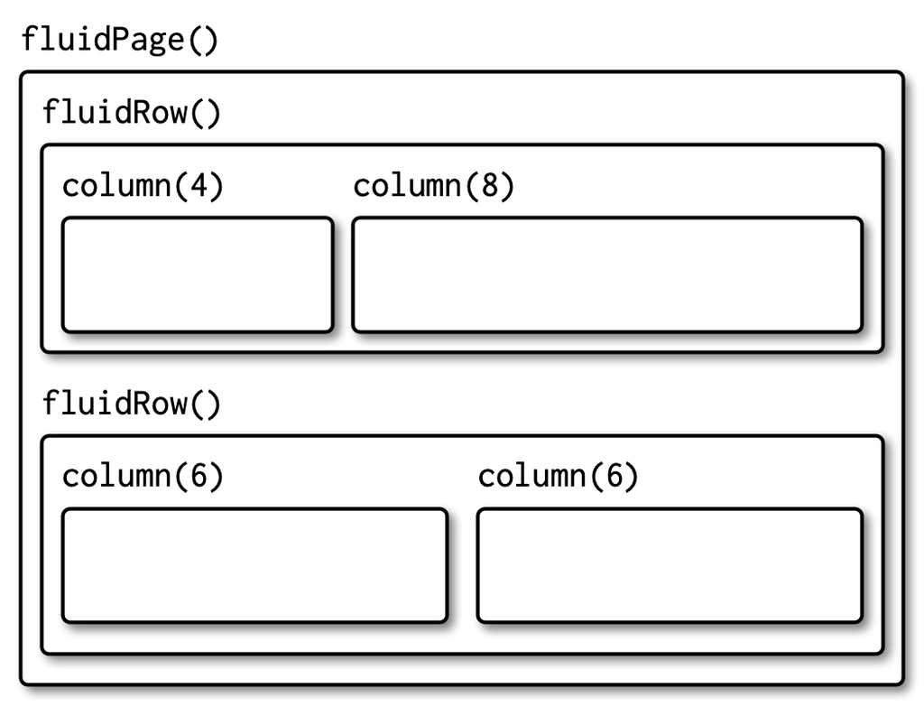

- Let’s make a shiny app with two input columns in one row, and three plot columns in a second row.

  ```r
  library(shiny)
  library(ggplot2)

  ui <- fluidPage(
    fluidRow(title = "Inputs",
             column(6,
                    selectInput("var1", "Variable 1", choices = names(mtcars)),
                    selectInput("var2", "Variable 2", choices = names(mtcars))
             ),
             column(6,
                    sliderInput("bins", "Number of Bins", min = 1, max = 50, value = 20)
             )
    ),
    fluidRow(title = "Outputs",
             column(4,
                    plotOutput("plot1")
             ),
             column(4,
                    plotOutput("plot2")
             ),
             column(4,
                    plotOutput("plot3")
             )
    )
  )

  server <- function(input, output) {
    output$plot1 <- renderPlot({
      ggplot(mtcars, aes(x = .data[[input$var1]], y = .data[[input$var2]])) +
        geom_point()
    })

    output$plot2 <- renderPlot({
      ggplot(mtcars, aes(x = .data[[input$var1]])) +
        geom_histogram(bins = input$bins)
    })

    output$plot3 <- renderPlot({
      ggplot(mtcars, aes(x = .data[[input$var2]])) +
        geom_histogram(bins = input$bins)
    })
  }

  shinyApp(ui = ui, server = server)
  ```

- Running the app, you should get something like this:

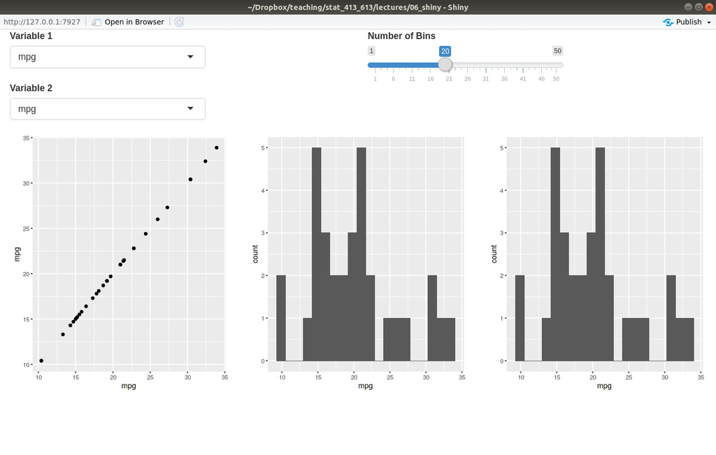

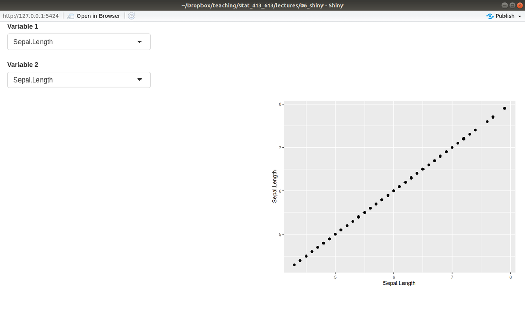

## Tabsets

  ```r
  library(shiny)
  library(ggplot2)

  ui <- fluidPage(
    sidebarLayout(
      sidebarPanel(
        selectInput("var1", "Variable 1", choices = names(mtcars)),
        selectInput("var2", "Variable 2", choices = names(mtcars)),
        sliderInput("bins", "Number of Bins", min = 1, max = 50, value = 20)
      ),
      mainPanel(
        tabsetPanel(
          tabPanel("Scatterplot",
                   plotOutput("plot1")
          ),
          tabPanel("Histogram of Variable 1",
                   plotOutput("plot2")
          ),
          tabPanel("Histogram of Variable 2",
                   plotOutput("plot3")
          )
        )
      )
    )
  )

  server <- function(input, output) {
    output$plot1 <- renderPlot({
      ggplot(mtcars, aes(x = .data[[input$var1]], y = .data[[input$var2]])) +
        geom_point()
    })

    output$plot2 <- renderPlot({
      ggplot(mtcars, aes(x = .data[[input$var1]])) +
        geom_histogram(bins = input$bins)
    })

    output$plot3 <- renderPlot({
      ggplot(mtcars, aes(x = .data[[input$var2]])) +
        geom_histogram(bins = input$bins)
    })
  }

  shinyApp(ui = ui, server = server)
  ```

- Running the app, you should get something like this:

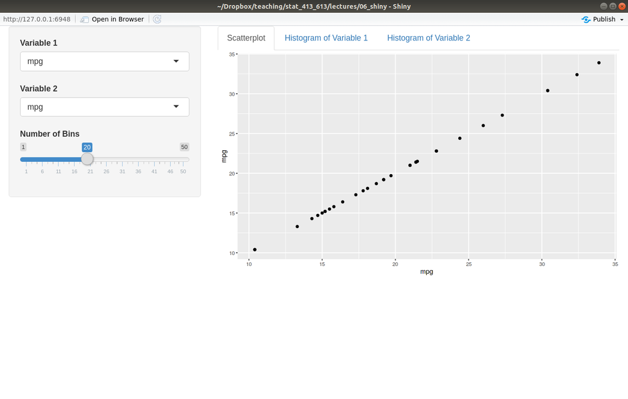

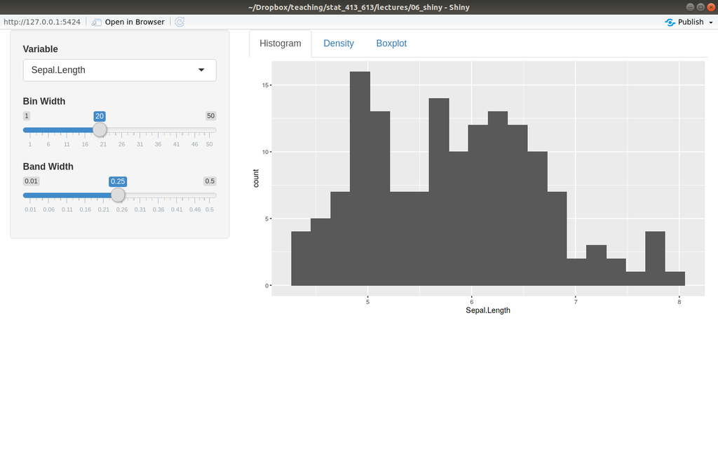

# Group Elements Together

- You can group elements together in a slightly inset border with `wellPanel()`.

[figure not shown]

  ```r
  library(shiny)
  library(ggplot2)

  ui <- fluidPage(
    wellPanel(
      sliderInput("bins", "How many bins?", min = 1, max = 50, value = 20),
      plotOutput("hist")
    )
  )

  server <- function(input, output, session) {
    output$hist <- renderPlot({
      ggplot(mtcars, aes(x = mpg)) +
        geom_histogram(bins = input$bins)
    })
  }

  shinyApp(ui, server)
  ```

- There are many other visual styles for groupings.

# Other Panels

- Here are some other panels you can look at to group elements together.
  - `absolutePanel()`.
  - `conditionalPanel()`.
  - `fixedPanel()`.
  - `headerPanel()`.
  - `inputPanel()`.
  - `navlistPanel()`.

# Shiny Themes

- For extreme customizability on the look of your Shiny App, you’ll have to learn [CSS](https://en.wikipedia.org/wiki/Cascading_Style_Sheets).
- We will not learn CSS.
- But the shinythemes package allows you to access many different themes available in Bootstrap.
- Inside `fluidPage()`, list the `theme` argument to be `shinytheme("theme_name")`, where `"theme_name"` is one of the themes that comes with shinythemes.
- The full list of available themes can be found by

  ```r
  help("shinythemes")
  ```

- Example:

  ```r
  library(shiny)
  library(shinythemes)

  ui <- fluidPage(theme = shinytheme("darkly"),
                  sidebarLayout(
                    sidebarPanel(
                      sliderInput("number", "select a number", 0, 100, 40)
                      ),
                    mainPanel(
                      tabsetPanel(
                        tabPanel("a"),
                        tabPanel("b"),
                        tabPanel("c")
                        )
                      )
                  )
  )

  server <- function(input, output, session) {

  }

  shinyApp(ui, server)
  ```

[figure not shown]

# Shiny Dashboards

- The shinydashboard package lets you obtain more proffesional looking Shiny apps.
- The only thing that changes in a shinydashboard is the user interface.
- The structure of a shinydashboard looks like this:

  ```r
  library(shiny)
  library(shinydashboard)

  ui <- dashboardPage(
    dashboardHeader(),
    dashboardSidebar(),
    dashboardBody()
  )

  server <- function(input, output, session) {

  }

  shinyApp(ui, server)
  ```

- `dashboardHeader()` just changes the title of the Shiny app.
- `dashboardSidebar()` is where you place a menu.
- `dashboardBody()` is where you place content.
- Use `fluidRow()` and `box()` (or `column()`) to add content to `dashboardBody()`.

  ```r
  library(shiny)
  library(shinydashboard)
  library(ggplot2)

  ui <- dashboardPage(
    dashboardHeader(),
    dashboardSidebar(),
    dashboardBody(
      fluidRow(
        box(
          plotOutput("hist")
        ),

        box(
          sliderInput("nobs", "Number of observations", min = 1, max = 100, value = 50),
          title = "Controls"
        )
      )
      )
  )

  server <- function(input, output, session) {
    output$hist <- renderPlot({
      x <- rnorm(input$nobs)
      qplot(x, bins = 10)
    })
  }

  shinyApp(ui, server)
  ```

- Create tabs by:
  - using `sidebarMenu()` and `menuItem()` in `dashboardSidebar()`.
  - using `tabItems()` and `tabitem()` in `dashboardBody()`.

    ```r
    library(shiny)
    library(shinydashboard)
    library(ggplot2)

    ui <- dashboardPage(
      dashboardHeader(),
      dashboardSidebar(
        sidebarMenu(
          menuItem(text = "Histogram", tabName = "tabhist"),
          menuItem(text = "Scatterplot", tabName = "tabscat")
        )
        ),
      dashboardBody(
        tabItems(
          tabItem(tabName = "tabhist",
            fluidRow(
              box(
                plotOutput("hist")
              ),

              box(
                sliderInput("nobs", "Number of observations",
                            min = 1,
                            max = 100,
                            value = 50),
                title = "Controls"
              )
            )
          ),
          tabItem(tabName = "tabscat",
            fluidRow(
              box(
                plotOutput("scatter")
              ),
              box(
                sliderInput("nobs2", "Number of observations",
                            min = 1,
                            max = 100,
                            value = 50),
                sliderInput("corr", "Correlation",
                            min = 0,
                            max = 1,
                            value = 0,
                            step = 0.1),
                title = "Controls"
                )
            )
          )
        )
      )
    )

    server <- function(input, output, session) {
      output$hist <- renderPlot({
        x <- rnorm(input$nobs)
        qplot(x, bins = 10)
      })

      output$scatter <- renderPlot({
        x <- rnorm(n = input$nobs2)
        y <- rnorm(n    = input$nobs2,
                   mean = input$corr * x,
                   sd   = sqrt(1 - input$corr^2))
        qplot(x, y)
      })
    }

    shinyApp(ui, server)
    ```

- Use the `skin` argument in `dashboardPage()` to change the appearence of your dashboard.
- For more information on shinydashboards, see: https://rstudio.github.io/shinydashboard/index.html